# assignment

Marco Fiorani Borraccino

2026-03-29

```r
suppressPackageStartupMessages({
  library(AnnotationHub)
  library(GenomicRanges)
  library(ggplot2)
  library(memes) # for the meme-based methods -- COMMENT OUT when using alternatives
  library(motifmatchr) # for scanning sequences for matches of given motifs
  library(Biostrings) # for handling sequences
  library(MotifDb) # database of motifs
  library(TFBSTools) # for handling some motif formats
  library(universalmotif) # for converting motifs to various formats
  library(PWMEnrich) # for R-based motif enrichment analysis
  library(GenomeInfoDb)
})
```

### Downloading POU5F1/Oct4 peaks found on chromosome 1,2,3 of hESC:

```r
download.file("https://www.encodeproject.org/files/ENCFF614KWI/@@download/ENCFF614KWI.bed.gz", "hESC_POU5F1_ENCFF614KWI.bed.gz")
peaks <- rtracklayer::import("hESC_POU5F1_ENCFF614KWI.bed.gz", format="NarrowPeak")
seqlevelsStyle(peaks) <- "Ensembl"  # to change the convention of the chromosome names to ensembl (i.e. without 'chr')

#Filter only the three biggest chromosomes (due to my limited computing power)
peaks_filtered <- peaks[seqnames(peaks) %in% c("1", "2", "3")]
#Drop the unused chromosome levels from the peaks object
peaks_filtered <- GenomeInfoDb::keepSeqlevels(peaks_filtered, c("1", "2", "3"), pruning.mode = "coarse")
```

### Downloading the corresponding genome of the experiment

```r
ah <- AnnotationHub()
genome <- ah[["AH106283"]] #GRCh38
```

```
## loading from cache
```

```
## require("rtracklayer")
```

```r
#Importing only chr 1,2,3
hgenome <- rtracklayer::import(genome, which = GenomicRanges::GRanges(c("1", "2", "3"), IRanges::IRanges(1, seqlengths(genome)[c("1", "2", "3")])))
names(hgenome) <- c("1", "2", "3")

#Finding right ID (AHXXXXX)
#grch38_matches <- AnnotationHub::query(ah, c("TwoBit", "Homo sapiens", "GRCh38"))
#grch38_matches
```

### Motif scanning

#### Getting the desired motif

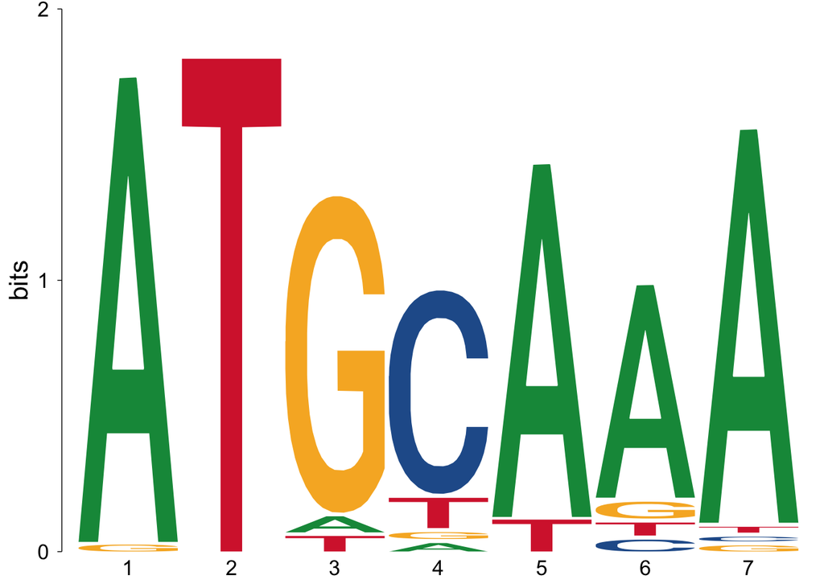

```
##  [1] "Mmusculus-JASPAR_CORE-Pou5f1-MA0142.1"
##  [2] "Mmusculus-JASPAR_2014-Pou5f1::Sox2-MA0142.1"
##  [3] "Mmusculus-jaspar2016-Pou5f1::Sox2-MA0142.1"
##  [4] "Hsapiens-jaspar2016-POU5F1B-MA0792.1"
##  [5] "Mmusculus-jaspar2018-Pou5f1::Sox2-MA0142.1"
##  [6] "Hsapiens-jaspar2018-POU5F1B-MA0792.1"
##  [7] "Hsapiens-jaspar2018-POU5F1-MA1115.1"
##  [8] "Mmusculus-jaspar2022-Pou5f1::Sox2-MA0142.1"
##  [9] "Hsapiens-jaspar2022-POU5F1B-MA0792.1"
## [10] "Hsapiens-jaspar2022-POU5F1-MA1115.1"
## [11] "Mmusculus-jaspar2024-Pou5f1::Sox2-MA0142.1"
## [12] "Hsapiens-jaspar2024-POU5F1B-MA0792.1"
## [13] "Hsapiens-jaspar2024-POU5F1-MA1115.2"
## [14] "Hsapiens-jolma2013-POU5F1P1"
## [15] "Hsapiens-jolma2013-POU5F1P1-2"
## [16] "Hsapiens-SwissRegulon-POU5F1.SwissRegulon"
##             1           2          3          4           5          6
## A 0.967896904 0.006329114 0.05467439 0.04064359 0.896446546 0.80524630
## C 0.009303035 0.009913070 0.01464084 0.78618271 0.010065579 0.05261553
## G 0.017462254 0.005109044 0.88233948 0.04178740 0.008998017 0.07823700
## T 0.005337807 0.978648772 0.04834528 0.13138630 0.084489858 0.06390117
##            7
## A 0.93640384
## C 0.02058868
## G 0.01959738
## T 0.02341010
```

```r
# we search for "POU5F1" in the motif database
motifs <- query(MotifDb, c("POU5F1"))
# there are several matching motifs:
names(motifs)
#Choosing the most updated, so 2024, version 2:
motif <- motifs[["Hsapiens-jaspar2024-POU5F1-MA1115.2"]]
motif
view_motifs(motif)
```

## Identify the instances of the factor’s motif in my hgenome

### 1. Of all the peaks, what proportion contains a motif for the factor?

```r
#Convert the genome to fasta
Biostrings::writeXStringSet(hgenome, "hgenome.fa")
#Convert the motif to a format that this package will accept
motif_converted <- universalmotif::convert_motifs(motif, class="TFBSTools-PWMatrix")
```

```
## Note: motif [motif] has an empty nsites slot, using 100.
```

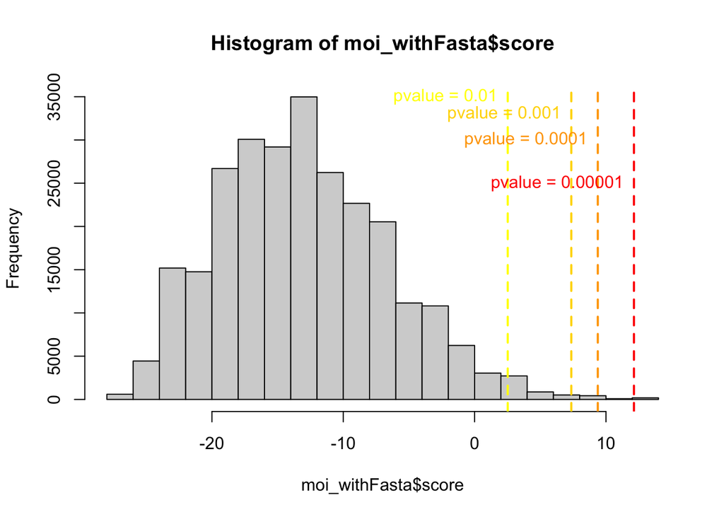

```r
#Get raw counts (not probabilities) for the whole genome
genome_counts <- colSums(Biostrings::alphabetFrequency(hgenome))
#Extract only A, C, G, T
acgt_counts <- genome_counts[c("A", "C", "G", "T")]
#Calculate the proportions (renormalize to 1): background of my hgenome with chr1,2,3 calculated by matchMotifs by default
my_bg <- acgt_counts / sum(acgt_counts)
#Calculate my_threshold for a specific pvalue
my_threshold_00001 <- universalmotif::motif_pvalue(motif_converted, pvalue = 0.00001, bkg = my_bg)
my_threshold_0001 <- universalmotif::motif_pvalue(motif_converted, pvalue = 0.0001, bkg = my_bg)
my_threshold_001 <- universalmotif::motif_pvalue(motif_converted, pvalue = 0.001, bkg = my_bg)
my_threshold_01 <- universalmotif::motif_pvalue(motif_converted, pvalue = 0.01, bkg = my_bg)

#Get the genomic positions of each motif match using p.value = 1 (I'll filter by score afterwards, I just want to plot the histograms of all scores)
moi_withFasta <- motifmatchr::matchMotifs(motif_converted, subject=peaks_filtered, genome=Rsamtools::FaFile("hgenome.fa"), out="positions", p.cutoff = 1)[[1]]
moi_default <- motifmatchr::matchMotifs(motif_converted, subject=peaks_filtered, genome=Rsamtools::FaFile("hgenome.fa"), out="positions")[[1]]

#Histograms with all possible matches (p.cutoff = 1)
h<-hist(moi_withFasta$score)
#Add the vertical line at my_threshold_
abline(v = my_threshold_00001, col = "red", lwd = 2, lty = 2)
abline(v = my_threshold_0001, col = "orange", lwd = 2, lty = 2)
abline(v = my_threshold_001, col = "gold", lwd = 2, lty = 2)
abline(v = my_threshold_01, col = "yellow", lwd = 2, lty = 2)
# pos = 2 sposta il testo a sinistra della coordinata x
text(x = my_threshold_00001, y = max(h$counts)-10000, labels = "pvalue = 0.00001", pos = 2, col = "red")
text(x = my_threshold_0001, y = max(h$counts)-5000, labels = "pvalue = 0.0001", pos = 2, col = "orange")
text(x = my_threshold_001, y = max(h$counts)-2000, labels = "pvalue = 0.001", pos = 2, col = "gold")
text(x = my_threshold_01, y = max(h$counts), labels = "pvalue = 0.01", pos = 2, col = "yellow")
```

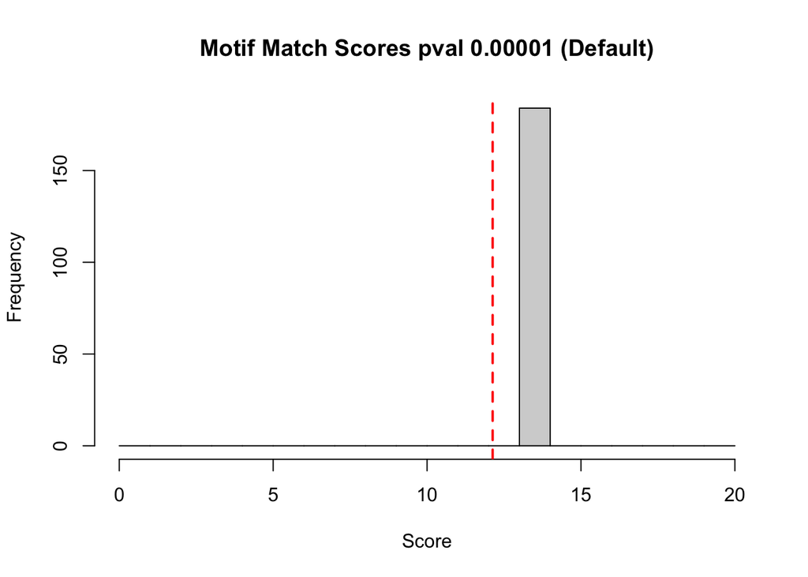

```r
#Filter by my_threshold == pvalue = 0.00001
moi_00001 <- moi_withFasta[moi_withFasta$score >= my_threshold_00001]
moi_0001 <- moi_withFasta[moi_withFasta$score >= my_threshold_0001]
moi_001 <- moi_withFasta[moi_withFasta$score >= my_threshold_001]
moi_01 <- moi_withFasta[moi_withFasta$score >= my_threshold_01]

#Histogram of filtered moi per pvalue
hist(moi_00001$score,
     breaks = seq(0, 20, by = 1),
     main = "Motif Match Scores pval 0.00001 (Default)",
     xlab = "Score")
abline(v = my_threshold_00001, col = "red", lwd = 2, lty = 2)
```

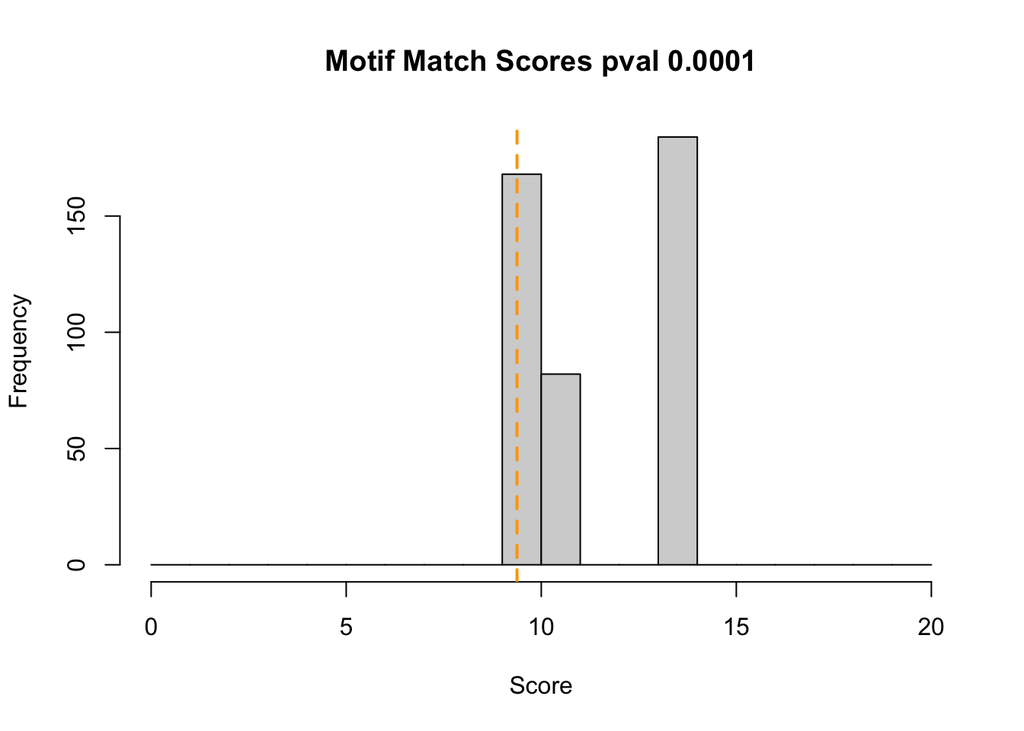

```r
hist(moi_0001$score,
     breaks = seq(0, 20, by = 1),
     main = "Motif Match Scores pval 0.0001",
     xlab = "Score")
abline(v = my_threshold_0001, col = "orange", lwd = 2, lty = 2)
```

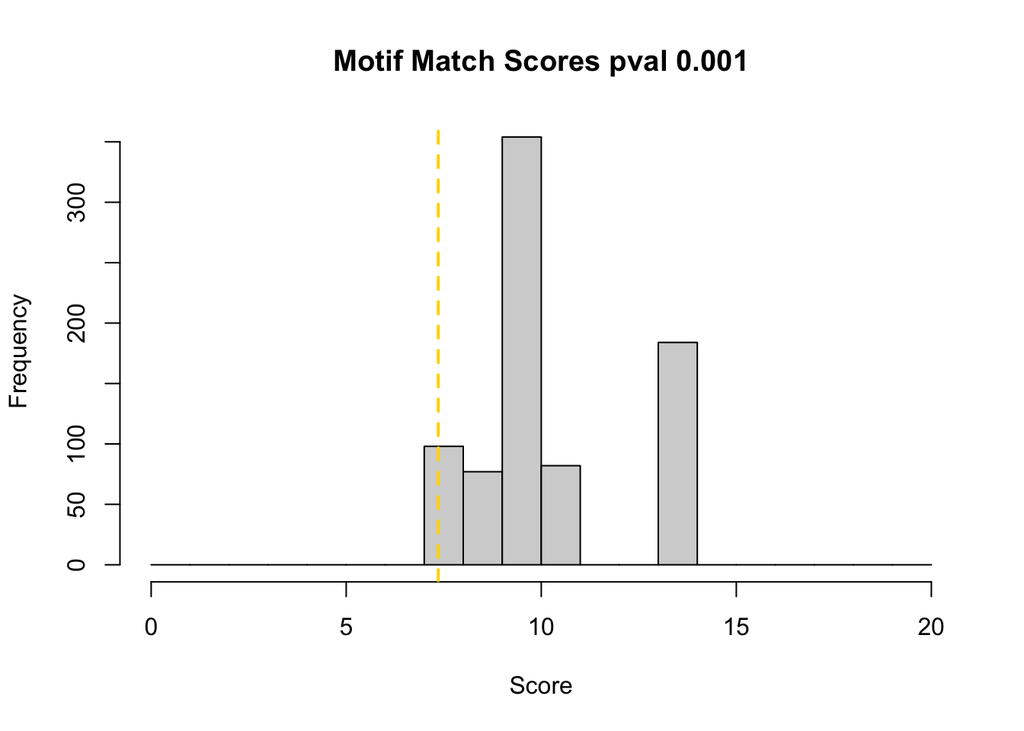

```r
hist(moi_001$score,
     breaks = seq(0, 20, by = 1),
     main = "Motif Match Scores pval 0.001",
     xlab = "Score")
abline(v = my_threshold_001, col = "gold", lwd = 2, lty = 2)
```

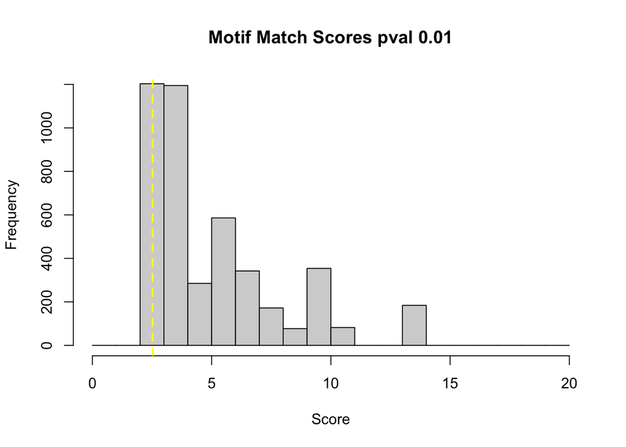

```r
hist(moi_01$score,
     breaks = seq(0, 20, by = 1),
     main = "Motif Match Scores pval 0.01",
     xlab = "Score")
abline(v = my_threshold_01, col = "yellow", lwd = 2, lty = 2)
```

```r
#Found number of peaks with at least one motif and the percentage
peaks_with_atleast1_motif_00001 <- subsetByOverlaps(peaks_filtered, moi_00001)
peaks_with_atleast1_motif_0001 <- subsetByOverlaps(peaks_filtered, moi_0001)
peaks_with_atleast1_motif_001 <- subsetByOverlaps(peaks_filtered, moi_001)
peaks_with_atleast1_motif_01 <- subsetByOverlaps(peaks_filtered, moi_01)
peaks_with_atleast1_motif_default <- subsetByOverlaps(peaks_filtered, moi_default)

#Conclusion printed
tot_peaks <- length(peaks_filtered)

cat(
  sprintf("Among all %d peaks:\n",
          tot_peaks),

  sprintf("For a pvalue default we found %d matches and %.2f%% of peaks (%d) contain at least one motif.\n",
          length(moi_default), (length(peaks_with_atleast1_motif_default) / tot_peaks) * 100, length(peaks_with_atleast1_motif_default)),

  sprintf("For a pvalue 0.00001 we found %d matches and %.2f%% of peaks (%d) contain at least one motif.\n",
          length(moi_00001), (length(peaks_with_atleast1_motif_00001) / tot_peaks) * 100, length(peaks_with_atleast1_motif_00001)),

  sprintf("For a pvalue 0.0001 we found %d matches and %.2f%% of peaks (%d) contain at least one motif.\n",
          length(moi_0001), (length(peaks_with_atleast1_motif_0001) / tot_peaks) * 100, length(peaks_with_atleast1_motif_0001)),

  sprintf("For a pvalue 0.001 we found %d matches and %.2f%% of peaks (%d) contain at least one motif.\n",
          length(moi_001), (length(peaks_with_atleast1_motif_001) / tot_peaks) * 100, length(peaks_with_atleast1_motif_001)),

  sprintf("For a pvalue 0.01 we found %d matches and %.2f%% of peaks (%d) contain at least one motif.\n",
          length(moi_01), (length(peaks_with_atleast1_motif_01) / tot_peaks) * 100, length(peaks_with_atleast1_motif_01))
)
```

```
## Among all 612 peaks:
##  For a pvalue default we found 184 matches and 25.82% of peaks (158) contain at least one motif.
##  For a pvalue 0.00001 we found 184 matches and 25.82% of peaks (158) contain at least one motif.
##  For a pvalue 0.0001 we found 434 matches and 53.27% of peaks (326) contain at least one motif.
##  For a pvalue 0.001 we found 795 matches and 76.47% of peaks (468) contain at least one motif.
##  For a pvalue 0.01 we found 4480 matches and 99.84% of peaks (611) contain at least one motif.
```

#### The extreme variability of these results based on p-value thresholds demonstrates how easily data can be manipulated to favor a prior hypothesis. By selecting a stringent default like 10^-5, a researcher could argue the transcription factor is highly selective and rarely relies on the motif (26%); conversely, relaxing the threshold to 10^-3 would “prove” the motif is present in the vast majority of peaks (76%). This flexibility allows authors to essentially “choose” their narrative by shifting a statistical cutoff until the data aligns with their expectations, highlighting the potential for bias in published articles. To maintain scientific integrity, it is essential to use **standardized thresholds** and transparently report results to prevent “p-hacking”.

### 2. Of all instances of that motif in the genome (or in one chromosome), what proportion is bound by the factor (i.e. has a peak)?

```r
# Get the genomic positions of each motif match across the WHOLE genome
#moi_withFasta <- motifmatchr::matchMotifs(motif_converted, subject=hgenome, genome=Rsamtools::FaFile("hgenome.fa"), out="positions", p.cutoff = 0.1)[[1]]
genome_moi_default_00001 <- motifmatchr::matchMotifs(motif_converted, subject=hgenome, out="positions")[[1]]
genome_moi_default_001 <- motifmatchr::matchMotifs(motif_converted, subject=hgenome, out="positions", p.cutoff = 0.001)[[1]]


#Debug to solve many past errors (thanks to LLM::Gemini)
#Force chromosome names
names(genome_moi_default_00001) <- names(hgenome)
names(genome_moi_default_001) <- names(hgenome)
#Convert to a simple Data Frame (This clears the "restricted" metadata)
df_moi_00001 <- as.data.frame(genome_moi_default_00001)
df_moi_001 <- as.data.frame(genome_moi_default_001)
#Rebuild the GRanges from the table
#Note: 'group_name' is where as.data.frame stores the chromosome names
genome_moi_gr_00001 <- GRanges(seqnames = df_moi_00001$group_name, ranges = IRanges(start = df_moi_00001$start, end = df_moi_00001$end),score = df_moi_00001$score)
genome_moi_gr_001<- GRanges(seqnames = df_moi_001$group_name, ranges = IRanges(start = df_moi_001$start, end = df_moi_001$end),score = df_moi_001$score)
#Standardize naming ("chr1" vs "1")
seqlevelsStyle(genome_moi_gr_00001) <- seqlevelsStyle(peaks_filtered)
seqlevelsStyle(genome_moi_gr_001) <- seqlevelsStyle(peaks_filtered)
genome_moi_default_00001 <- genome_moi_gr_00001
genome_moi_default_001 <- genome_moi_gr_001

#Find overlaps between motif instances and peaks of Chip-seq
bound_motifs_00001 <- subsetByOverlaps(genome_moi_default_00001, peaks_filtered)
bound_motifs_001 <- subsetByOverlaps(genome_moi_default_001, peaks_filtered)

tot_instances_00001 <- length(genome_moi_default_00001)
tot_instances_001 <- length(genome_moi_default_001)
instances_bound_00001 <- length(bound_motifs_00001)
instances_bound_001 <- length(bound_motifs_001)

cat(sprintf("Of the %d motif instances, %d (%.2f%%) overlap a peak (pval: 0.00001/default)\n", tot_instances_00001, instances_bound_00001, (instances_bound_00001/tot_instances_00001)*100))
cat(sprintf("Of the %d motif instances, %d (%.2f%%) overlap a peak(pval: 0.001)\n", tot_instances_001, instances_bound_001, (instances_bound_001/tot_instances_001)*100))
```

```
## Of the 206843 motif instances, 187 (0.09%) overlap a peak (pval: 0.00001/default)
## Of the 1716428 motif instances, 640 (0.04%) overlap a peak(pval: 0.001)
```